# Pinkeye

Alex Fonseca

4/27/2022

## Statistical analysis

This chunk imports the data and creates two datasets. One set of data for all the animals registered in the spreadsheet and another one where animals with a note are excluded (suspicion of pinkeye at enrollment). Additionally, we excluded one animal from further analyzes as its initial weight of 285 and final weight of 308 indicate an abnormally unusual weight gain for the observation period.

## Interaction plot between Bovis and Bovoculi for weaning weight using the full data.

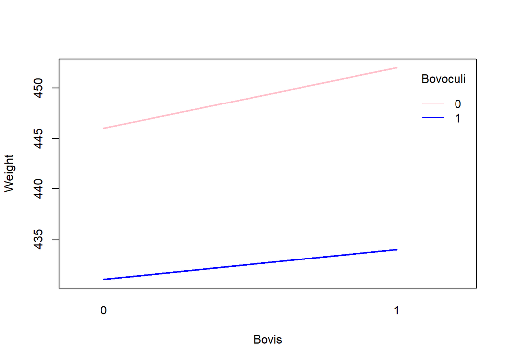

## Interaction plot excluding animals suspected of pinkeye

This interaction plot graphically displays the average weaning weight for animals vaccinated with M. bovis and M. bovoculi, excluding animals suspected of pinkeye. Since there is no crossing between the lines, we can say that there is no interaction. It means that the effect of vaccinate with Bovis on weaning weight is independent on vaccinate with Bovoculi.

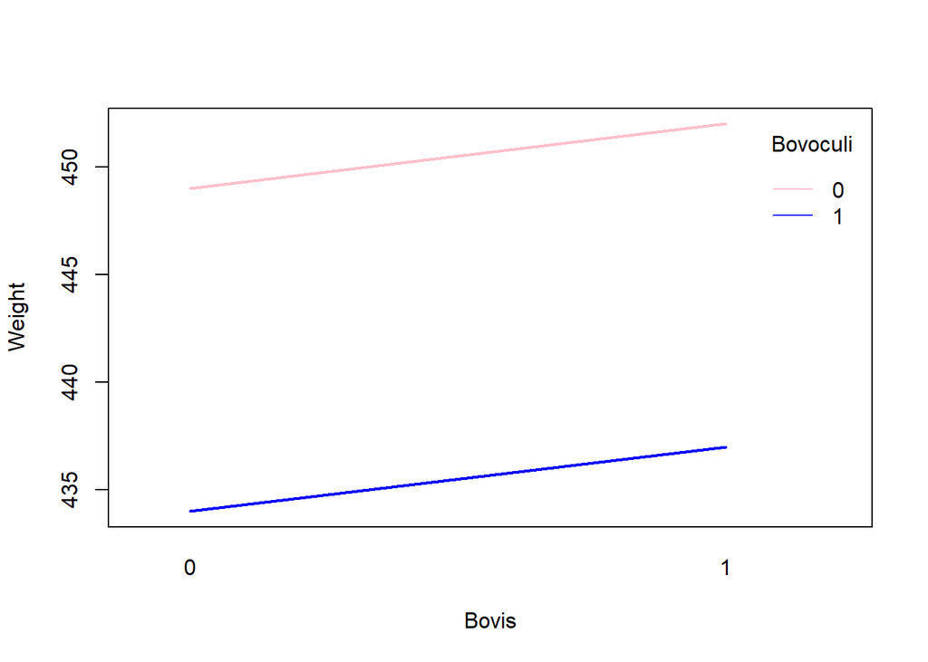

## Descriptive tables

### Full data set

The table summarizes the number of animals enrolled, their initial and final weight for all the animals.

| VACCINE | BOTH | BOVIS ONLY | BOVOCULI ONLY | NOTHING |
| --- | --- | --- | --- | --- |
| Animals allocated | 131 | 41 | 34 | 35 |
| Mean enrollment weight | 224.2519 | 222.7561 | 231.6176 | 241.2286 |
| Mean weaning weight | 438.5038 | 452.7561 | 436.5294 | 464.6857 |

```
##                        [,1]       [,2]         [,3]            [,4]
## VACCINE                "BOTH"     "BOVIS ONLY" "BOVOCULI ONLY" "NOTHING"
## Animals allocated      "131"      " 41"        " 34"           " 35"
## Mean enrollment weight "224.2519" "222.7561"   "231.6176"      "241.2286"
## Mean weaning weight    "438.5038" "452.7561"   "436.5294"      "464.6857"
```

### Summary table excluding suspected animals (with initial notes)

This table summarizes the number of animals enrolled, their initial and final weight excluding animals with initial notes (suspected pinkeye). Animals with the highest weight at enrollment were those that did not receive any vaccine (246.8 units), followed by those that received only Bovoculi, then those that received Bovis (232.6) and finally those that received both vaccines (227.5). On average the animals that received neither vaccine had the highest weaning weight (465.7) followed by those that received only Bovis (453.4), then those that received both (442.4) and finally those that received only Bovoculi (436).

A possible differential enrollment was analyzed by obtaining the percentage of animals without suspicion of pinkeye (187) from the total number of animals reported (241) for each vaccine category. Thus, 75.5% (99/131) of the animals that received both vaccines had no note (suspected pinkeye), 70.7% (29/41) of the animals that were vaccinated only with M bovis had no note, 82.3% (28/34) of the animals vaccinated only with M bovoculi had no note, and 88.5% (31/35) of the control animals had no note at all (suspected pinkeye). Since there are no large differences in such percentages, we conclude that there was no differential enrollment.

| VACCINE | BOTH | BOVIS ONLY | BOVOCULI ONLY | NOTHING |
| --- | --- | --- | --- | --- |
| Animals allocated | 99 | 29 | 28 | 31 |
| Mean enrollment weight | 227.4949 | 232.6552 | 233.7500 | 246.8065 |
| Mean weaning weight | 442.4343 | 453.4828 | 436.0357 | 465.7742 |

```
##                        [,1]       [,2]         [,3]            [,4]
## VACCINE                "BOTH"     "BOVIS ONLY" "BOVOCULI ONLY" "NOTHING"
## Animals allocated      "99"       "29"         "28"            "31"
## Mean enrollment weight "227.4949" "232.6552"   "233.7500"      "246.8065"
## Mean weaning weight    "442.4343" "453.4828"   "436.0357"      "465.7742"
```

### Data set excluding any note

The table summarizes the number of animals enrolled, their initial and final weight for all the animals.

| VACCINE | BOTH | BOVIS ONLY | BOVOCULI ONLY | NOTHING |
| --- | --- | --- | --- | --- |
| Animals allocated | 70 | 22 | 22 | 28 |
| Mean enrollment weight | 226.1857 | 232.2727 | 234.4545 | 243.2143 |
| Mean weaning weight | 439.3857 | 451.5000 | 444.6818 | 457.5357 |

```
##                        [,1]       [,2]         [,3]            [,4]
## VACCINE                "BOTH"     "BOVIS ONLY" "BOVOCULI ONLY" "NOTHING"
## Animals allocated      "70"       "22"         "22"            "28"
## Mean enrollment weight "226.1857" "232.2727"   "234.4545"      "243.2143"
## Mean weaning weight    "439.3857" "451.5000"   "444.6818"      "457.5357"
```

### Data set excluding final notes like PE, watery eye etc

The table summarizes the number of animals enrolled, their initial and final weight for all the animals.

| VACCINE | BOTH | BOVIS ONLY | BOVOCULI ONLY | NOTHING |
| --- | --- | --- | --- | --- |
| Animals allocated | 87 | 27 | 23 | 29 |
| Mean enrollment weight | 226.7701 | 223.2593 | 229.8696 | 240.3103 |
| Mean weaning weight | 441.1149 | 445.1481 | 439.8696 | 456.8966 |

```
##                        [,1]       [,2]         [,3]            [,4]
## VACCINE                "BOTH"     "BOVIS ONLY" "BOVOCULI ONLY" "NOTHING"
## Animals allocated      "87"       "27"         "23"            "29"
## Mean enrollment weight "226.7701" "223.2593"   "229.8696"      "240.3103"
## Mean weaning weight    "441.1149" "445.1481"   "439.8696"      "456.8966"
```

### Data set excluding any note and animals with ORDER greater than 215

The table summarizes the number of animals enrolled, their initial and final weight for all the animals.

| VACCINE | BOTH | BOVIS ONLY | BOVOCULI ONLY | NOTHING |
| --- | --- | --- | --- | --- |
| Animals allocated | 66 | 17 | 22 | 25 |
| Mean enrollment weight | 222.6364 | 240.4118 | 234.4545 | 243.5600 |
| Mean weaning weight | 436.7121 | 451.8824 | 444.6818 | 456.8800 |

```
##                        [,1]       [,2]         [,3]            [,4]
## VACCINE                "BOTH"     "BOVIS ONLY" "BOVOCULI ONLY" "NOTHING"
## Animals allocated      "66"       "17"         "22"            "25"
## Mean enrollment weight "222.6364" "240.4118"   "234.4545"      "243.5600"
## Mean weaning weight    "436.7121" "451.8824"   "444.6818"      "456.8800"
```

### Data set excluding final notes like PE, watery eye etc and animals with ORDER greater than 215

The table summarizes the number of animals enrolled, their initial and final weight for all the animals.

| VACCINE | BOTH | BOVIS ONLY | BOVOCULI ONLY | NOTHING |
| --- | --- | --- | --- | --- |
| Animals allocated | 82 | 19 | 23 | 25 |
| Mean enrollment weight | 222.5732 | 237.4211 | 229.8696 | 243.5600 |
| Mean weaning weight | 437.4878 | 448.6842 | 439.8696 | 456.8800 |

```
##                        [,1]       [,2]         [,3]            [,4]
## VACCINE                "BOTH"     "BOVIS ONLY" "BOVOCULI ONLY" "NOTHING"
## Animals allocated      "82"       "19"         "23"            "25"
## Mean enrollment weight "222.5732" "237.4211"   "229.8696"      "243.5600"
## Mean weaning weight    "437.4878" "448.6842"   "439.8696"      "456.8800"
```

### Summary table Pinkeye, enrollment and final weight for full dataset

Summary table for mean enrollment/weaning weight to animals diagnosed with pinkeye (PD=1) and those without diagnosis (PD=0). This table includes all the animals initially enrolled (241).

| PD | 0 | 1 |
| --- | --- | --- |
| Animals allocated | 137 | 104 |
| Mean enrollment weight | 221.5182 | 235.3846 |
| Mean weaning weight | 442.2263 | 447.3846 |

```
##                        [,1]       [,2]
## PD                     "0"        "1"
## Animals allocated      "137"      "104"
## Mean enrollment weight "221.5182" "235.3846"
## Mean weaning weight    "442.2263" "447.3846"
```

### Summary table Pinkeye, enrollment and final weight excluding initial notes

Summary table for mean enrollment/weaning weight to animals diagnosed with pinkeye (PD=1) and those without diagnosis (PD=0). This table excludes animal with notes (187) (suspected pinkeye). During the trial 81 animals developed pinkeye and 106 remained negative. The average weight in the registration for the positive animals was 234.6 units and 230.7 units for the negative ones. Weaning weight for negative animals was slightly greater than that of pinkeye animals.

| PD | 0 | 1 |
| --- | --- | --- |
| Animals allocated | 106 | 81 |
| Mean enrollment weight | 230.7736 | 234.6049 |
| Mean weaning weight | 449.7736 | 443.5062 |

```
##                        [,1]       [,2]
## PD                     "0"        "1"
## Animals allocated      "106"      " 81"
## Mean enrollment weight "230.7736" "234.6049"
## Mean weaning weight    "449.7736" "443.5062"
```

### Summary table Pinkeye, enrollment and final weight excluding any kind of notes

| PED | 0 | 1 |
| --- | --- | --- |
| Animals allocated | 87 | 55 |
| Mean enrollment weight | 230.7586 | 233.3636 |
| Mean weaning weight | 448.8621 | 440.6000 |

```
##                        [,1]       [,2]
## PED                    "0"        "1"
## Animals allocated      "87"       "55"
## Mean enrollment weight "230.7586" "233.3636"
## Mean weaning weight    "448.8621" "440.6000"
```

### Summary table Pinkeye, enrollment and final weight excluding final notes

| PED | 0 | 1 |
| --- | --- | --- |
| Animals allocated | 102 | 64 |
| Mean enrollment weight | 224.6765 | 235.8750 |
| Mean weaning weight | 442.3529 | 447.5469 |

```
##                        [,1]       [,2]
## PED                    "0"        "1"
## Animals allocated      "102"      " 64"
## Mean enrollment weight "224.6765" "235.8750"
## Mean weaning weight    "442.3529" "447.5469"
```

### Summary table Pinkeye, enrollment and final weight excluding any kind of notes and animal with ORDER greater than 215

| PED | 0 | 1 |
| --- | --- | --- |
| Animals allocated | 81 | 49 |
| Mean enrollment weight | 230.0123 | 232.5918 |
| Mean weaning weight | 447.5556 | 437.9184 |

```
##                        [,1]       [,2]
## PED                    "0"        "1"
## Animals allocated      "81"       "49"
## Mean enrollment weight "230.0123" "232.5918"
## Mean weaning weight    "447.5556" "437.9184"
```

### Summary table Pinkeye, enrollment and final weight excluding final notes and animal with ORDER greater than 215

| PED | 0 | 1 |
| --- | --- | --- |
| Animals allocated | 95 | 54 |
| Mean enrollment weight | 224.3474 | 237.5000 |
| Mean weaning weight | 441.3895 | 444.5556 |

```
##                        [,1]       [,2]
## PED                    "0"        "1"
## Animals allocated      "95"       "54"
## Mean enrollment weight "224.3474" "237.5000"
## Mean weaning weight    "441.3895" "444.5556"
```

## Effect of vaccine on pinkeye ocurrence

The table shows the number of animals diagnosed with pinkeye (PD=1) according to the vaccine received. A chi-square test was performed to establish an association between pinkeye and the type of vaccine received. It is concluded that the type of vaccine received is not related to the increase or decrease in the incidence of pinkeye (p>0.05).

| **VACCINE** | PD 0 | PD 0 | PD 0 | PD 0 | PD 1 | PD 1 | PD 1 | PD 1 | Total | Total | Total | Total |
| --- | --- | --- | --- | --- | --- | --- | --- | --- | --- | --- | --- | --- |
| **BOTH** | 52 | ( | 52.5% | ) | 47 | ( | 47.5% | ) | 99 | ( | 100.0% | ) |
| **BOVIS ONLY** | 16 | ( | 55.2% | ) | 13 | ( | 44.8% | ) | 29 | ( | 100.0% | ) |
| **BOVOCULI ONLY** | 18 | ( | 64.3% | ) | 10 | ( | 35.7% | ) | 28 | ( | 100.0% | ) |
| **NOTHING** | 20 | ( | 64.5% | ) | 11 | ( | 35.5% | ) | 31 | ( | 100.0% | ) |
| **Total** | 106 | ( | 56.7% | ) | 81 | ( | 43.3% | ) | 187 | ( | 100.0% | ) |

**Χ<sup>2</sup>** = 2.1578 **df** = 3 **p** = .5403

## Effect of vaccine on pinkeye occurrence adjusting for enrollment weight

A logistic regression was performed to establish the association between pinkeye and type of vaccine received, adjusted for the initial weight of the animals and excluding animals with notes (pinkeye suspicion). After adjusting for initial weight, it is concluded that the type of vaccine received is not related to the increase or decrease in the incidence of pinkeye.

```
##
## Call:
## glm(formula = PD ~ relevel(VACCINE, ref = "NOTHING") + Weight,
##     family = "binomial", data = dataPD_WO_NOTES)
##
## Deviance Residuals:
##     Min       1Q   Median       3Q      Max
## -1.2040  -1.1012  -0.9168   1.2337   1.5306
##
## Coefficients:
##                                                 Estimate Std. Error z value
## (Intercept)                                    -1.001114   0.756306  -1.324
## relevel(VACCINE, ref = "NOTHING")BOTH           0.529262   0.429842   1.231
## relevel(VACCINE, ref = "NOTHING")BOVIS ONLY     0.414155   0.531491   0.779
## relevel(VACCINE, ref = "NOTHING")BOVOCULI ONLY  0.031326   0.546132   0.057
## Weight                                          0.001629   0.002643   0.616
##                                                Pr(>|z|)
## (Intercept)                                       0.186
## relevel(VACCINE, ref = "NOTHING")BOTH             0.218
## relevel(VACCINE, ref = "NOTHING")BOVIS ONLY       0.436
## relevel(VACCINE, ref = "NOTHING")BOVOCULI ONLY    0.954
## Weight                                            0.538
##
## (Dispersion parameter for binomial family taken to be 1)
##
##     Null deviance: 255.88  on 186  degrees of freedom
## Residual deviance: 253.32  on 182  degrees of freedom
## AIC: 263.32
##
## Number of Fisher Scoring iterations: 4
```

## Effect of vaccine on pinkeye occurrence adjusting for enrollment weight excluding any kind of note

```
##
## Call:
## glm(formula = PED ~ relevel(VACCINE, ref = "NOTHING") + initial_weight,
##     family = "binomial", data = data_WO_any_notes)
##
## Deviance Residuals:
##     Min       1Q   Median       3Q      Max
## -1.1312  -1.0218  -0.8751   1.3127   1.5591
##
## Coefficients:
##                                                 Estimate Std. Error z value
## (Intercept)                                    -1.035306   0.860082  -1.204
## relevel(VACCINE, ref = "NOTHING")BOTH           0.421442   0.475244   0.887
## relevel(VACCINE, ref = "NOTHING")BOVIS ONLY     0.578418   0.590591   0.979
## relevel(VACCINE, ref = "NOTHING")BOVOCULI ONLY -0.004309   0.611863  -0.007
## initial_weight                                  0.001181   0.003103   0.381
##                                                Pr(>|z|)
## (Intercept)                                       0.229
## relevel(VACCINE, ref = "NOTHING")BOTH             0.375
## relevel(VACCINE, ref = "NOTHING")BOVIS ONLY       0.327
## relevel(VACCINE, ref = "NOTHING")BOVOCULI ONLY    0.994
## initial_weight                                    0.703
##
## (Dispersion parameter for binomial family taken to be 1)
##
##     Null deviance: 189.58  on 141  degrees of freedom
## Residual deviance: 187.83  on 137  degrees of freedom
## AIC: 197.83
##
## Number of Fisher Scoring iterations: 4
```

## Effect of vaccine on pinkeye occurrence adjusting for enrollment weight excluding final notes

```
##
## Call:
## glm(formula = PED ~ relevel(VACCINE, ref = "NOTHING") + initial_weight,
##     family = "binomial", data = data_WO_final_notes)
##
## Deviance Residuals:
##     Min       1Q   Median       3Q      Max
## -1.1925  -0.9871  -0.8821   1.2822   1.6801
##
## Coefficients:
##                                                 Estimate Std. Error z value
## (Intercept)                                    -1.535743   0.793563  -1.935
## relevel(VACCINE, ref = "NOTHING")BOTH           0.298206   0.452030   0.660
## relevel(VACCINE, ref = "NOTHING")BOVIS ONLY     0.485719   0.555670   0.874
## relevel(VACCINE, ref = "NOTHING")BOVOCULI ONLY -0.146167   0.601563  -0.243
## initial_weight                                  0.003692   0.002828   1.305
##                                                Pr(>|z|)
## (Intercept)                                       0.053 .
## relevel(VACCINE, ref = "NOTHING")BOTH             0.509
## relevel(VACCINE, ref = "NOTHING")BOVIS ONLY       0.382
## relevel(VACCINE, ref = "NOTHING")BOVOCULI ONLY    0.808
## initial_weight                                    0.192
## ---
## Signif. codes:  0 '***' 0.001 '**' 0.01 '*' 0.05 '.' 0.1 ' ' 1
##
## (Dispersion parameter for binomial family taken to be 1)
##
##     Null deviance: 221.35  on 165  degrees of freedom
## Residual deviance: 218.27  on 161  degrees of freedom
## AIC: 228.27
##
## Number of Fisher Scoring iterations: 4
```

## Effect of vaccine on final weight

A linear regression was performed to analyze the effect of the type of vaccine received on the final weight of the animals. The results indicate that the type of vaccine does not have a significant effect on the weaning weight.

```
##
## Call:
## lm(formula = Weaning.Weight ~ relevel(VACCINE, ref = "NOTHING"),
##     data = dataPD_WO_NOTES)
##
## Residuals:
##      Min       1Q   Median       3Q      Max
## -221.036  -46.235   -5.036   47.896  203.226
##
## Coefficients:
##                                                Estimate Std. Error t value
## (Intercept)                                      465.77      12.76  36.515
## relevel(VACCINE, ref = "NOTHING")BOTH            -23.34      14.62  -1.597
## relevel(VACCINE, ref = "NOTHING")BOVIS ONLY      -12.29      18.35  -0.670
## relevel(VACCINE, ref = "NOTHING")BOVOCULI ONLY   -29.74      18.52  -1.606
##                                                Pr(>|t|)
## (Intercept)                                      <2e-16 ***
## relevel(VACCINE, ref = "NOTHING")BOTH             0.112
## relevel(VACCINE, ref = "NOTHING")BOVIS ONLY       0.504
## relevel(VACCINE, ref = "NOTHING")BOVOCULI ONLY    0.110
## ---
## Signif. codes:  0 '***' 0.001 '**' 0.01 '*' 0.05 '.' 0.1 ' ' 1
##
## Residual standard error: 71.02 on 183 degrees of freedom
## Multiple R-squared:  0.01868,    Adjusted R-squared:  0.002597
## F-statistic: 1.161 on 3 and 183 DF,  p-value: 0.3259
```

## Effect of vaccine on final weight excluding any kind of note

```
##
## Call:
## lm(formula = WeaningWeight ~ relevel(VACCINE, ref = "NOTHING"),
##     data = data_WO_any_notes)
##
## Residuals:
##      Min       1Q   Median       3Q      Max
## -194.386  -44.136   -5.943   41.577  166.614
##
## Coefficients:
##                                                Estimate Std. Error t value
## (Intercept)                                     457.536     12.975  35.263
## relevel(VACCINE, ref = "NOTHING")BOTH           -18.150     15.352  -1.182
## relevel(VACCINE, ref = "NOTHING")BOVIS ONLY      -6.036     19.560  -0.309
## relevel(VACCINE, ref = "NOTHING")BOVOCULI ONLY  -12.854     19.560  -0.657
##                                                Pr(>|t|)
## (Intercept)                                      <2e-16 ***
## relevel(VACCINE, ref = "NOTHING")BOTH             0.239
## relevel(VACCINE, ref = "NOTHING")BOVIS ONLY       0.758
## relevel(VACCINE, ref = "NOTHING")BOVOCULI ONLY    0.512
## ---
## Signif. codes:  0 '***' 0.001 '**' 0.01 '*' 0.05 '.' 0.1 ' ' 1
##
## Residual standard error: 68.66 on 138 degrees of freedom
## Multiple R-squared:  0.01136,    Adjusted R-squared:  -0.01013
## F-statistic: 0.5287 on 3 and 138 DF,  p-value: 0.6633
```

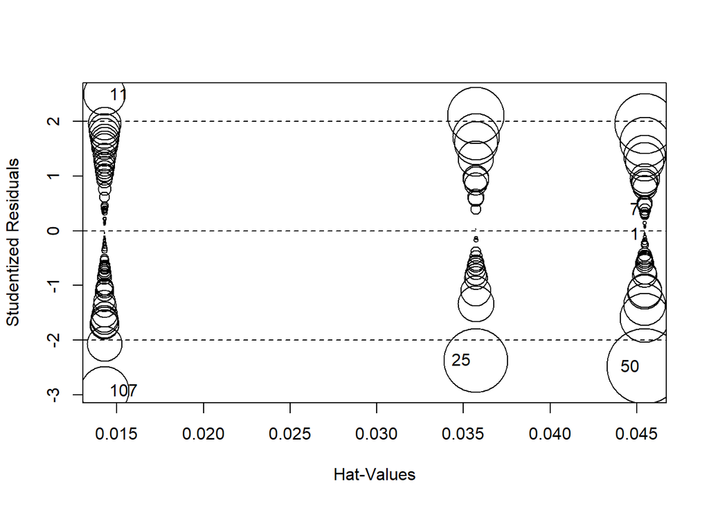

```
##         StudRes        Hat        CookD
## 1   -0.06684383 0.04545455 5.357815e-05
## 7    0.39114697 0.04545455 1.832629e-03
## 11   2.48993270 0.01428571 2.164726e-02
## 25  -2.37564867 0.03571429 5.055535e-02
## 50  -2.48553481 0.04545455 7.088650e-02
## 107 -2.92899012 0.01428571 2.946505e-02
```

```
## No Studentized residuals with Bonferroni p < 0.05
## Largest |rstudent|:
##     rstudent unadjusted p-value Bonferroni p
## 107 -2.92899          0.0039844      0.56578
```

## Effect of vaccine on final weight excluding final notes

```
##
## Call:
## lm(formula = WeaningWeight ~ relevel(VACCINE, ref = "NOTHING"),
##     data = data_WO_final_notes)
##
## Residuals:
##      Min       1Q   Median       3Q      Max
## -196.115  -48.060   -6.115   40.049  164.885
##
## Coefficients:
##                                                Estimate Std. Error t value
## (Intercept)                                      456.90      12.82  35.647
## relevel(VACCINE, ref = "NOTHING")BOTH            -15.78      14.80  -1.066
## relevel(VACCINE, ref = "NOTHING")BOVIS ONLY      -11.75      18.46  -0.636
## relevel(VACCINE, ref = "NOTHING")BOVOCULI ONLY   -17.03      19.27  -0.884
##                                                Pr(>|t|)
## (Intercept)                                      <2e-16 ***
## relevel(VACCINE, ref = "NOTHING")BOTH             0.288
## relevel(VACCINE, ref = "NOTHING")BOVIS ONLY       0.525
## relevel(VACCINE, ref = "NOTHING")BOVOCULI ONLY    0.378
## ---
## Signif. codes:  0 '***' 0.001 '**' 0.01 '*' 0.05 '.' 0.1 ' ' 1
##
## Residual standard error: 69.02 on 162 degrees of freedom
## Multiple R-squared:  0.007656,   Adjusted R-squared:  -0.01072
## F-statistic: 0.4166 on 3 and 162 DF,  p-value: 0.7413
```

## Effect of vaccine on final weight adjusting for enrollment weight

A linear regression was performed to analyze the effect of the type of vaccine received on the final weight, adjusting for the initial weight of the animals. The results indicate that the type of vaccine does not have a significant effect on the final weight after adjusting for the initial weight.

```
##
## Call:
## lm(formula = Weaning.Weight ~ relevel(VACCINE, ref = "NOTHING") +
##     Weight_10, data = dataPD_WO_NOTES)
##
## Residuals:
##     Min      1Q  Median      3Q     Max
## -96.614 -29.869  -1.677  21.075 133.041
##
## Coefficients:
##                                                  Estimate Std. Error t value
## (Intercept)                                    225.126734  16.322304  13.793
## relevel(VACCINE, ref = "NOTHING")BOTH           -4.510262   9.211506  -0.490
## relevel(VACCINE, ref = "NOTHING")BOVIS ONLY      1.506703  11.506654   0.131
## relevel(VACCINE, ref = "NOTHING")BOVOCULI ONLY -17.007848  11.607532  -1.465
## Weight_10                                        0.097505   0.005769  16.901
##                                                Pr(>|t|)
## (Intercept)                                      <2e-16 ***
## relevel(VACCINE, ref = "NOTHING")BOTH             0.625
## relevel(VACCINE, ref = "NOTHING")BOVIS ONLY       0.896
## relevel(VACCINE, ref = "NOTHING")BOVOCULI ONLY    0.145
## Weight_10                                        <2e-16 ***
## ---
## Signif. codes:  0 '***' 0.001 '**' 0.01 '*' 0.05 '.' 0.1 ' ' 1
##
## Residual standard error: 44.43 on 182 degrees of freedom
## Multiple R-squared:  0.6181, Adjusted R-squared:  0.6097
## F-statistic: 73.63 on 4 and 182 DF,  p-value: < 2.2e-16
```

## Effect of vaccine on final weight adjusting for enrollment weight and excluding any king of note

```
##
## Call:
## lm(formula = WeaningWeight ~ relevel(VACCINE, ref = "NOTHING") +
##     initial_weight, data = data_WO_any_notes)
##
## Residuals:
##     Min      1Q  Median      3Q     Max
## -94.198 -28.833   0.233  22.501 135.373
##
## Coefficients:
##                                                 Estimate Std. Error t value
## (Intercept)                                    228.05992   17.88522  12.751
## relevel(VACCINE, ref = "NOTHING")BOTH           -2.08332    9.76683  -0.213
## relevel(VACCINE, ref = "NOTHING")BOVIS ONLY      4.28779   12.38372   0.346
## relevel(VACCINE, ref = "NOTHING")BOVOCULI ONLY  -4.58897   12.37630  -0.371
## initial_weight                                   0.94351    0.06535  14.438
##                                                Pr(>|t|)
## (Intercept)                                      <2e-16 ***
## relevel(VACCINE, ref = "NOTHING")BOTH             0.831
## relevel(VACCINE, ref = "NOTHING")BOVIS ONLY       0.730
## relevel(VACCINE, ref = "NOTHING")BOVOCULI ONLY    0.711
## initial_weight                                   <2e-16 ***
## ---
## Signif. codes:  0 '***' 0.001 '**' 0.01 '*' 0.05 '.' 0.1 ' ' 1
##
## Residual standard error: 43.39 on 137 degrees of freedom
## Multiple R-squared:  0.6079, Adjusted R-squared:  0.5965
## F-statistic:  53.1 on 4 and 137 DF,  p-value: < 2.2e-16
```

## Effect of vaccine on final weight adjusting for enrollment weight and excluding final notes

```
##
## Call:
## lm(formula = WeaningWeight ~ relevel(VACCINE, ref = "NOTHING") +
##     initial_weight, data = data_WO_final_notes)
##
## Residuals:
##     Min      1Q  Median      3Q     Max
## -94.774 -29.100  -1.018  23.311 133.686
##
## Coefficients:
##                                                 Estimate Std. Error t value
## (Intercept)                                    228.80552   15.83187  14.452
## relevel(VACCINE, ref = "NOTHING")BOTH           -2.92987    9.06000  -0.323
## relevel(VACCINE, ref = "NOTHING")BOVIS ONLY      4.43567   11.30061   0.393
## relevel(VACCINE, ref = "NOTHING")BOVOCULI ONLY  -7.11710   11.76957  -0.605
## initial_weight                                   0.94915    0.05729  16.568
##                                                Pr(>|t|)
## (Intercept)                                      <2e-16 ***
## relevel(VACCINE, ref = "NOTHING")BOTH             0.747
## relevel(VACCINE, ref = "NOTHING")BOVIS ONLY       0.695
## relevel(VACCINE, ref = "NOTHING")BOVOCULI ONLY    0.546
## initial_weight                                   <2e-16 ***
## ---
## Signif. codes:  0 '***' 0.001 '**' 0.01 '*' 0.05 '.' 0.1 ' ' 1
##
## Residual standard error: 42.1 on 161 degrees of freedom
## Multiple R-squared:  0.6331, Adjusted R-squared:  0.624
## F-statistic: 69.46 on 4 and 161 DF,  p-value: < 2.2e-16
```

## Effect of pinkeye on final weight

A linear regression was performed to analyze the pinkeye effect on the final weight of the animals. Although an animal diagnosed with pinkeye has an average decrease in weaning weight of 6.26 units, the association between weaning weight and incidence of pinkeye is not statistically significant.

```
##
## Call:
## lm(formula = Weaning.Weight ~ PD, data = dataPD_WO_NOTES)
##
## Residuals:
##      Min       1Q   Median       3Q      Max
## -228.506  -46.274   -2.506   47.726  219.226
##
## Coefficients:
##             Estimate Std. Error t value Pr(>|t|)
## (Intercept)  449.774      6.919  65.004   <2e-16 ***
## PD1           -6.267     10.513  -0.596    0.552
## ---
## Signif. codes:  0 '***' 0.001 '**' 0.01 '*' 0.05 '.' 0.1 ' ' 1
##
## Residual standard error: 71.24 on 185 degrees of freedom
## Multiple R-squared:  0.001917,   Adjusted R-squared:  -0.003478
## F-statistic: 0.3554 on 1 and 185 DF,  p-value: 0.5518
```

## Effect of pinkeye on final weight excluding any kind of note

```
##
## Call:
## lm(formula = WeaningWeight ~ PED, data = data_WO_any_notes)
##
## Residuals:
##      Min       1Q   Median       3Q      Max
## -195.600  -45.612   -1.862   46.888  157.400
##
## Coefficients:
##             Estimate Std. Error t value Pr(>|t|)
## (Intercept)  448.862      7.337  61.178   <2e-16 ***
## PED1          -8.262     11.789  -0.701    0.485
## ---
## Signif. codes:  0 '***' 0.001 '**' 0.01 '*' 0.05 '.' 0.1 ' ' 1
##
## Residual standard error: 68.43 on 140 degrees of freedom
## Multiple R-squared:  0.003496,   Adjusted R-squared:  -0.003622
## F-statistic: 0.4912 on 1 and 140 DF,  p-value: 0.4846
```

## Effect of pinkeye on final weight excluding final notes

```
##
## Call:
## lm(formula = WeaningWeight ~ PED, data = data_WO_final_notes)
##
## Residuals:
##     Min      1Q  Median      3Q     Max
## -202.55  -47.10   -1.45   47.65  163.65
##
## Coefficients:
##             Estimate Std. Error t value Pr(>|t|)
## (Intercept)  442.353      6.814  64.919   <2e-16 ***
## PED1           5.194     10.974   0.473    0.637
## ---
## Signif. codes:  0 '***' 0.001 '**' 0.01 '*' 0.05 '.' 0.1 ' ' 1
##
## Residual standard error: 68.82 on 164 degrees of freedom
## Multiple R-squared:  0.001364,   Adjusted R-squared:  -0.004725
## F-statistic: 0.224 on 1 and 164 DF,  p-value: 0.6366
```

## Effect of pinkeye on final weight adjusting for enrollment weight

Similarly, a linear regression was performed to analyze the effect of pinkeye on weaning weight, adjusting for the initial weight of the animals. It is observed that animals with pinkeye lose an average of 10.02 units of weight at weaning, although the association between pinkeye and weaning weight is not statistically significant.

```
##
## Call:
## lm(formula = Weaning.Weight ~ Weight_10 + PD, data = dataPD_WO_NOTES)
##
## Residuals:
##      Min       1Q   Median       3Q      Max
## -100.433  -26.522   -3.464   23.366  135.901
##
## Coefficients:
##              Estimate Std. Error t value Pr(>|t|)
## (Intercept) 223.47408   13.86094  16.123   <2e-16 ***
## Weight_10     0.09806    0.00571  17.174   <2e-16 ***
## PD1         -10.02449    6.53759  -1.533    0.127
## ---
## Signif. codes:  0 '***' 0.001 '**' 0.01 '*' 0.05 '.' 0.1 ' ' 1
##
## Residual standard error: 44.27 on 184 degrees of freedom
## Multiple R-squared:  0.6166, Adjusted R-squared:  0.6124
## F-statistic: 147.9 on 2 and 184 DF,  p-value: < 2.2e-16
```

## Effect of pinkeye on final weight adjusting for enrollment weight excluding all kind of notes

```
##
## Call:
## lm(formula = WeaningWeight ~ initial_weight + PED, data = data_WO_any_notes)
##
## Residuals:
##    Min     1Q Median     3Q    Max
## -91.33 -24.22  -1.24  22.84 132.51
##
## Coefficients:
##                Estimate Std. Error t value Pr(>|t|)
## (Intercept)    230.3473    15.4879  14.873   <2e-16 ***
## initial_weight   0.9469     0.0641  14.773   <2e-16 ***
## PED1           -10.7289     7.3819  -1.453    0.148
## ---
## Signif. codes:  0 '***' 0.001 '**' 0.01 '*' 0.05 '.' 0.1 ' ' 1
##
## Residual standard error: 42.84 on 139 degrees of freedom
## Multiple R-squared:  0.6123, Adjusted R-squared:  0.6067
## F-statistic: 109.8 on 2 and 139 DF,  p-value: < 2.2e-16
```

## Effect of pinkeye on final weight adjusting for enrollment weight excluding final notes

```
##
## Call:
## lm(formula = WeaningWeight ~ initial_weight + PED, data = data_WO_final_notes)
##
## Residuals:
##     Min      1Q  Median      3Q     Max
## -92.107 -27.582  -1.957  23.154 133.618
##
## Coefficients:
##                Estimate Std. Error t value Pr(>|t|)
## (Intercept)    228.2146    13.4624  16.952   <2e-16 ***
## initial_weight   0.9531     0.0570  16.720   <2e-16 ***
## PED1            -5.4793     6.7108  -0.816    0.415
## ---
## Signif. codes:  0 '***' 0.001 '**' 0.01 '*' 0.05 '.' 0.1 ' ' 1
##
## Residual standard error: 41.89 on 163 degrees of freedom
## Multiple R-squared:  0.6322, Adjusted R-squared:  0.6277
## F-statistic: 140.1 on 2 and 163 DF,  p-value: < 2.2e-16
```